Email [GitHub](https://github.com/patrickabolger) [LinkedIn](https://www.linkedin.com/in/patrick-bolger-66b1b41/) [Google Scholar](https://scholar.google.com/citations?hl=en&user=2Eb1mO4AAAAJ) [ResearchGate](https://www.researchgate.net/profile/Patrick_Bolger)

I currently work as a Senior Lecturer in Psychology at Nottingham Trent University, where I have taught various modules, including the following (sorted by student level):

# Teaching

## Undergraduate

### First year

- *Developing Academic Skills in Psychology*
- *Introduction to Developmental Psychology*
- *Research Methods & Statistics*

### Second year

- *Social & Developmental Psychology*
- *Individual Differences*
- *Research Methods & Statistics*

### Third year

- *Psychology of the Family*
- Projects (supervisor)

## Postgraduate (Master’s)

- *The Child in Context*
- *Social & Developmental Psychology*
- *Developmental Profiles of Language and Learning*
- *Research Skills in Applied Child Psychology*
- *AI and Cyberpsychology*

# Research

I am part of the [Language, Literacy, and Psycholinguistics Research Group](https://www.ntu.ac.uk/research/groups-and-centres/groups/language-literacy-and-psycholinguistics)

My research interests are as follows:

- psycholinguistics (bilingualism, skilled reading)
- diversity, equity, and inclusion in the unrelated areas of open-source software development and the teaching of statistics
- the incorporation of large language models into educational contexts, especially writing and statistics

# Service

- I have served on the Course Team as a Year Tutor
  - the first-year tutor on Single Honours (general pathway)
  - the third-year tutor for Combined Honours
- I have also been the module leader on four modules

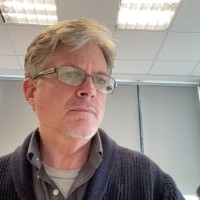